# Assignment2 for Week2

YujieWang

2022-10-12

## Load packages

```r
library(tidyverse)
```

**Load the Stat2Data package and then the dataset Hawks**

```r
library(Stat2Data)
data("Hawks")
```

## 1. Data Wrangling

### 1.1 Select and filter

**(Q1)** Use a combination of the select() and filter() functions to generate a data frame called “hSF” which is a sub-table of the original Hawks data frame., such that 1. Your data frame should include the columns: a) “Wing” b) “Weight” c) “Tail” 2. Your data frame should contain a row for every hawk such that: a) They belong to the species of Red-Tailed hawks b) They have weight at least 1kg. 3. Use the pipe operator to simplify your code.

```r
head(Hawks)
```

```
##   Month Day Year CaptureTime ReleaseTime  BandNumber Species Age Sex Wing
## 1     9  19 1992       13:30               877-76317      RT   I      385
## 2     9  22 1992       10:30               877-76318      RT   I      376
## 3     9  23 1992       12:45               877-76319      RT   I      381
## 4     9  23 1992       10:50               745-49508      CH   I   F  265
## 5     9  27 1992       11:15              1253-98801      SS   I   F  205
## 6     9  28 1992       11:25             1207-55910       RT   I      412
##   Weight Culmen Hallux Tail StandardTail Tarsus WingPitFat KeelFat Crop
## 1    920   25.7   30.1  219           NA     NA         NA      NA   NA
## 2    930     NA     NA  221           NA     NA         NA      NA   NA
## 3    990   26.7   31.3  235           NA     NA         NA      NA   NA
## 4    470   18.7   23.5  220           NA     NA         NA      NA   NA
## 5    170   12.5   14.3  157           NA     NA         NA      NA   NA
## 6   1090   28.5   32.2  230           NA     NA         NA      NA   NA
```

```r
hsF<-Hawks%>%filter(Species=='RT' & Weight>=1000)%>%select(Wing,Weight,Tail)
print(hsF)
```

```
##      Wing Weight Tail
## 1   412.0   1090  230
## 2   412.0   1210  210
## 3   405.0   1120  238
## 4   393.0   1010  222
## 5   371.0   1010  217
## 6   390.0   1120  213
## 7   416.0   1170  243
## 8   436.0   1390  232
## 9   418.0   1150  238
## 10  396.0   1010  227
## 11  399.0   1070  222
## 12  416.0   1190  237
## 13  392.0   1330  213
## 14  399.0   1100  190
```

[output cut: 384 more lines]

```r
hsFSpecies<-Hawks%>%group_by(Species)%>%summarize(n_rows=n())
print(hsFSpecies)
```

```
## # A tibble: 3 × 2
##   Species n_rows
##   <fct>    <int>
## 1 CH          70
## 2 RT         577
## 3 SS         261
```

**(Q2)** How many variables does the data frame hSF have? What would you say to communicate this information to a Machine Learning practitioner?

Variables:3–Wing,Weight,Tail Examples:398

```r
hsF%>%summarize(n_rows=n())
```

```
##   n_rows
## 1    398
```

### 1.2 The arrange function

**(Q1)** Use the arrange() function to sort the hSF data frame created in the previous section so that the rows appear in order of increasing wing span. Then use the head command to print out the top five rows of your sorted data frame.

```r
head(hsF%>%arrange(Wing),5)
```

```
##    Wing Weight Tail
## 1  37.2   1180  210
## 2 111.0   1340  226
## 3 199.0   1290  222
## 4 241.0   1320  235
## 5 262.0   1020  200
```

### 1.3 Join and rename functions

The species of Hawks within the data frame have been indicated via a two-letter code (e.g., RT, CH, SS). The correspondence between these codes and the full names is given by the following data frame: |species_code|species_name_full| |————|—————–| |CH |Cooper’s| |RT |Red-tailed| |SS |Sharp-shinned|

**(Q1)** Use data.frame() to create a data frame that is called hawkSpeciesNameCodes and is the same as the above data frame (i.e., containing the correspondence between codes and the full species names).

```r
species_code<-c("CH","RT","SS")
species_name_full<-c("Cooper's","Red-tailed","Sharp-shinned")
hawkSpeciesNameCodes<-data.frame(species_code,species_name_full)
print(hawkSpeciesNameCodes)
```

```
##   species_code species_name_full
## 1           CH          Cooper's
## 2           RT        Red-tailed
## 3           SS     Sharp-shinned
```

**(Q2)** Use a combination of the functions *left_join()*, the *rename()* and the *select()* functions to create a new data frame called “hawksFullName” which is the same as the “Hawks” data frame except that the Species column contains the full names rather than the two-letter codes.

```r
print(hawkSpeciesNameCodes)
```

```
##   species_code species_name_full
## 1           CH          Cooper's
## 2           RT        Red-tailed
## 3           SS     Sharp-shinned
```

```r
hawkSpecies2<-hawkSpeciesNameCodes%>%rename(Species=species_code)
print(hawkSpeciesNameCodes)
```

```
##   species_code species_name_full
## 1           CH          Cooper's
## 2           RT        Red-tailed
## 3           SS     Sharp-shinned
```

```r
hawksFullName<-left_join(Hawks,hawkSpecies2)%>%select(-Species)%>%rename(Species=species_name_full)
#如果是right_join的话结果有区别吗
hawksFullName2<-right_join(Hawks,hawkSpecies2)%>%select(-Species)
print(hawksFullName)
```

```
##     Month Day Year CaptureTime ReleaseTime  BandNumber Age Sex  Wing Weight
## 1       9  19 1992       13:30               877-76317   I     385.0    920
## 2       9  22 1992       10:30               877-76318   I     376.0    930
## 3       9  23 1992       12:45               877-76319   I     381.0    990
## 4       9  23 1992       10:50               745-49508   I   F 265.0    470
## 5       9  27 1992       11:15              1253-98801   I   F 205.0    170
## 6       9  28 1992       11:25             1207-55910    I     412.0   1090
## 7       9  28 1992       13:30               877-76320   I     370.0    960
## 8       9  29 1992       11:45               877-76321   A     375.0    855
## 9       9  29 1992       15:35               877-76322   A     412.0   1210
## 10      9  30 1992       13:45              1207-55911   I     405.0   1120
## 11     10   5 1992       13:30               877-76323   I     393.0   1010
## 12     10   8 1992       13:45               877-76324   I     371.0   1010
## 13     10   9 1992       12:30               877-76325   A     390.0   1120
## 14     10  10 1992       11:05              1207-55917   A     393.0     NA
```

[output cut: 2712 more lines]

```r
print(hawksFullName2)
```

```
##     Month Day Year CaptureTime ReleaseTime  BandNumber Age Sex  Wing Weight
## 1       9  19 1992       13:30               877-76317   I     385.0    920
## 2       9  22 1992       10:30               877-76318   I     376.0    930
## 3       9  23 1992       12:45               877-76319   I     381.0    990
## 4       9  23 1992       10:50               745-49508   I   F 265.0    470
## 5       9  27 1992       11:15              1253-98801   I   F 205.0    170
## 6       9  28 1992       11:25             1207-55910    I     412.0   1090
## 7       9  28 1992       13:30               877-76320   I     370.0    960
## 8       9  29 1992       11:45               877-76321   A     375.0    855
## 9       9  29 1992       15:35               877-76322   A     412.0   1210
## 10      9  30 1992       13:45              1207-55911   I     405.0   1120
## 11     10   5 1992       13:30               877-76323   I     393.0   1010
## 12     10   8 1992       13:45               877-76324   I     371.0   1010
## 13     10   9 1992       12:30               877-76325   A     390.0   1120
## 14     10  10 1992       11:05              1207-55917   A     393.0     NA
```

[output cut: 2712 more lines]

**(Q3)** Use a combination of the *head()* and *select()* functions to print out the top seven rows of the columns “Species”, “Wing” and “Weight” of the data frame called “hawksFullName”. Do this without modifying the data frame you just created.

```r
hawksFullName%>%select(Species,Wing,Weight)%>%head(7)
```

```
##         Species Wing Weight
## 1    Red-tailed  385    920
## 2    Red-tailed  376    930
## 3    Red-tailed  381    990
## 4      Cooper's  265    470
## 5 Sharp-shinned  205    170
## 6    Red-tailed  412   1090
## 7    Red-tailed  370    960
```

right_join 和left_join没有区别因为Species只有三种

### 1.4 The mutate function

Suppose that the fictitious “Healthy Hawks Society”1 has proposed a new measure called the “bird BMI” which attempts to measure the mass of a hawk standardized by their wing span. The “bird BMI” is equal to the weight of the hawk (in grams) divided by their wing span (in millimeters) squared. That is, $Bird-BMI := 1000 × Weight/(Wingspan)^2$

**(Q1)** Use the *mutate()*, *select()* and *arrange()* functions to create a new data frame called “hawksWithBMI” which has the same number of rows as the original Hawks data frame but only two columns -one with their Species and one with their “bird BMI”. Also, arrange the rows in descending order of “bird BMI”. The top 8 rows of your data frame should look something like this:

```r
hawksWithBMI<-Hawks%>%mutate(bird_BMI=1000*Weight/Wing^2)%>%select(Species,bird_BMI)%>%arrange(desc(bird_BMI))
print(head(hawksWithBMI,8))
```

```
##   Species  bird_BMI
## 1      RT 852.69973
## 2      RT 108.75741
## 3      RT  32.57493
## 4      RT  22.72688
## 5      CH  22.40818
## 6      RT  19.54932
## 7      CH  15.21998
## 8      RT  14.85927
```

### 1.5 Summarize and group-by functions

Using the data frame “hawksFullName”, from problem 3 above, to do the following tasks:

**(Q1)** In combination with the *summarize()* and the *group_by functions*, create a summary table, broken down by Hawk species, which contains the following summary quantities: 1. The number of rows (num_rows); 2. The average wing span in centimeters (mn_wing); 3. The median wing span in centimeters (nd_wing); 4. The trimmed average wing span in centimeters with trim=0.1, i.e., the mean of the numbers after the 10% largest and the 10% smallest values being removed (t_mn_wing); 5. The biggest ratio between wing span and tail length (b_wt_ratio).

```r
hawksFullName%>%group_by(Species)%>%summarize(num_rows=n(),mn_wing=round(mean(Wing),digits=0),nd_wing=median(Wing,na.rm=TRUE),t_mn_wing=round(mean(Wing,trim=0.1),digits=0),b_wt_ratio=round(max(Wing/Tail,na.rm=TRUE),digits=2))
```

```
## # A tibble: 3 × 6
##   Species       num_rows mn_wing nd_wing t_mn_wing b_wt_ratio
##   <chr>            <int>   <dbl>   <dbl>     <dbl>      <dbl>
## 1 Cooper's            70      NA     240        NA       1.67
## 2 Red-tailed         577     383     384       385       3.16
## 3 Sharp-shinned      261     185     191       184       1.67
```

**(Q2)** Next create a summary table of the following form: Your summary table will show the number of missing values, broken down by species, for the columns Wing, Weight, Culmen, Hallux, Tail, StandardTail,Tarsus, and Crop. You can complete this task by combining the *select()*, *group_by()*, *summarize()*,*across()*, *everything()*, *sum()* and *is.na()* functions.

```r
hawksFullName%>%group_by(Species)%>%summarize(across(everything(),~sum(is.na(.x))))%>%select(Species,Wing,Weight,Culmen,Hallux,Tail,StandardTail,Tarsus,Crop)
```

```
## # A tibble: 3 × 9
##   Species        Wing Weight Culmen Hallux  Tail StandardTail Tarsus  Crop
##   <chr>         <int>  <int>  <int>  <int> <int>        <int>  <int> <int>
## 1 Cooper's          1      0      0      0     0           19     62    21
## 2 Red-tailed        0      5      4      3     0          250    538   254
## 3 Sharp-shinned     0      5      3      3     0           68    233    68
```

## 2.Tidy data and iteration

### 2.1 Missing data and iteration

**(Q1)** The following function performs imputation by mean. What library do we need to load to run this function?

```r
library(tidyverse)
impute_by_mean<-function(x){
  mu<-mean(x,na.rm=1) # first compute the mean of x
  impute_f<-function(z){ # coordinate-wise imputation
  if(is.na(z)){
  return(mu) # if z is na replace with mean
  }else{
  return(z) # otherwise leave in place
  } }
  return(map_dbl(x,impute_f)) # apply the map function to impute across vector
}
```

**(Q2)** Create a function called *impute_by_median* which imputes missing values based on the median of the sample, rather than the mean.

```r
impute_by_median<-function(x){
  mu<-median(x,na.rm=TRUE)
  impute_median<-function(z){
    if(is.na(z)){
      return(mu)
    }else{
      return(z)
    }
  }
  return(map_dbl(x,impute_median))
}
v<-c(1,2,NA,4)
c(impute_by_median(v))
```

```
## [1] 1 2 2 4
```

**(Q3)** Next generate a data frame with two variables x and y. For our first variable x we have a sequence (x1, x2, · · · , xn) where x1 = 0, xn = 10 and for each i = 1, · · · , n − 1, xi+1 = xi + 0.1. For our second variable y we set yi = 5xi + 1 for i = 1, · · · , n. Generate data of this form and place within a data frame called df_xy

```r
x<-c(seq(0,10,0.1))
z<-function(x){
  result<-5*x+1
  return(result)
}
y<-map_dbl(x,z)
df_xy<-data.frame(x,y)
df_xy%>%head(5)
```

```
##     x   y
## 1 0.0 1.0
## 2 0.1 1.5
## 3 0.2 2.0
## 4 0.3 2.5
## 5 0.4 3.0
```

The map2() function is similar to the map() function but iterates over two variables in parallel rather than one. You can learn more here https://purrr.tidyverse.org/reference/map2.html. The following simple example shows you how map2_dbl() can be combined with the mutate() function.

```r
x<-c(seq(0,10,0.1))
l<-function(x){
  result<-5*x+1
  return(result)
}
h<-function(x,y){
  result<-x+y
  return(result)
}
y<-map_dbl(x,l)
z<-map2_dbl(x,y,h)
df_xyz<-data.frame(x,y,z)
df_xyz%>%head(5)
```

```
##     x   y   z
## 1 0.0 1.0 1.0
## 2 0.1 1.5 1.6
## 3 0.2 2.0 2.2
## 4 0.3 2.5 2.8
## 5 0.4 3.0 3.4
```

**(Q4)** We will now use map2_dbl() to generate a new data frame with missing data. * First create a function *sometimes_missing* with two arguments: index and value. The function should return NA if index is divisible by 5 and returns value otherwise.

```r
sometimes_missing<-function(i,v){
  if(i%%5==0){
    return(NA)
  }else{
    return(v)
  }
}
print(sometimes_missing(14,25))
```

```
## [1] 25
```

```r
print(sometimes_missing(15,25))
```

```
## [1] NA
```

Next generate a new data frame called *df_xy_missing* with *two variables x and y*, but some missing data. For the first variable x we have a sequence (x1, · · · , xn), which is precisely the same as with df_xy. For the second variable y we have a sequence (y1, · · · , yn) where yi = NA if i is divisible by 5 and otherwise yi = 5xi + 1. To generate the data frame d_xy_missing you may want to make use of the functions row_number(), map2_dbl(), mutate() as well as sometimes_missing(). Check that the first ten rows of your data frame are as follows:

```r
library(dplyr)
```

```r
x<-c(seq(0,10,0.1))
sometimes_missing<-function(i,v){
    if(i%%5==0){
      return(NA)
    }else{
      return(5*v+1)
    }
}
y<-map2_dbl(row_number(x),x,sometimes_missing)
df_xy_missing<-data.frame(x,y)
df_xy_missing%>%head(10)
```

```
##      x   y
## 1  0.0 1.0
## 2  0.1 1.5
## 3  0.2 2.0
## 4  0.3 2.5
## 5  0.4  NA
## 6  0.5 3.5
## 7  0.6 4.0
## 8  0.7 4.5
## 9  0.8 5.0
## 10 0.9  NA
```

**(Q5)** Create a new data frame df_xy_imputed with two variables x and y. For the first variable x we have a sequence (x1, · · · , xn), which is precisely the same as with df_xy. For the second variable y we have a sequence (y1′ , · · · , y′n) which is formed from (y1, · · · , yn) by imputing any missing values with the median. To generate *df_xy_imputed* from *df_xy_missing* by applying a combination of the functions mutate() and impute_by_median().

```r
df_vy_imputed<-df_xy_missing%>%mutate(y=impute_by_median(y))%>%head(6)
print(df_vy_imputed)
```

```
##     x    y
## 1 0.0  1.0
## 2 0.1  1.5
## 3 0.2  2.0
## 4 0.3  2.5
## 5 0.4 26.0
## 6 0.5  3.5
```

### 2.2 Tidying data with pivot functions

In this task you will read in data from a spreadsheet and apply some data wrangling tasks to tidy that data. First download the excel spreadsheet entitled “HockeyLeague.xlsx”. The excel file contains two spread-sheets- one with the wins for each team and one with the losses for each team. To read this spreadsheet into R we shall make use of the *readxl* library. You may need to install the library: install.packages(“readxl”)

- The following code shows how to read in a sheet within an excel file as a data frame. You will need to edit the *folder_path* variable to be the directory which contains your copy of the spreadsheet

```r
library(readxl)
folder_path<-'/Users/yujiewang/MyProjects/R_Projects/Assignment2/Assignment2/'
file_name<-"HockeyLeague.xlsx"
file_path<-paste(folder_path,file_name,sep="")
wins_data_frame<-read_excel(file_path,sheet="Wins")
# read of a sheet from an xl file
```

```r
wins_data_frame%>%select(1:5)%>%head(3)
```

```
## # A tibble: 3 × 5
##   ...1   `1990`   `1991`   `1992`   `1993`
##   <chr>  <chr>    <chr>    <chr>    <chr>
## 1 Ducks  30 of 50 11 of 50 30 of 50 12 of 50
## 2 Eagles 24 of 50 12 of 50 37 of 50 14 of 50
## 3 Hawks  20 of 50 22 of 50 33 of 50 11 of 50
```

A cell value of the form “a of b” means that games were won out of a total of b for that season. For example,the element for the “Ducks” row of the “1990” column is “30 of 50” meaning that 30 out of 50 games were won that season.

**(Q1)** Now apply your data wrangling skills to transform the *“wins_data_frame”* data frame object into a data frame called *“wins_tidy”* which contains the same information but has just four columns entitled “Team”, “Year”, “Wins”, “Total”. The “Team” column should contain the team name, the “Year” column should contain the year, the “Wins” column should contain the number of wins for that season and the “Total” column the total number of games for that season. The first column should be of character type and the remaining columns should be of integer type. You can do this by combining the following functions: rename(), pivot_longer(), mutate() and separate().

```r
wins_tidy<-wins_data_frame%>%rename(Team=...1)%>%pivot_longer(-all_of('Team'),names_to="Year",values_to="Wins_Total")%>%separate(Wins_Total,into=c("Wins","Total"),sep="of",convert=TRUE)
```

```r
wins_tidy%>%dim()
```

```
## [1] 248   4
```

```r
wins_tidy%>%head(5)
```

```
## # A tibble: 5 × 4
##   Team  Year   Wins Total
##   <chr> <chr> <dbl> <int>
## 1 Ducks 1990     30    50
## 2 Ducks 1991     11    50
## 3 Ducks 1992     30    50
## 4 Ducks 1993     12    50
## 5 Ducks 1994     24    50
```

**(Q2)** The “HockeyLeague.xlsx” also contains a sheet with the losses for each team by season. Apply a similar procedure to read the data from this sheet and transform that data into a data frame called 6 “losses_tidy” with four columns: “Team”, “Year”, “Losses”, “Total” which are similar to those in the “wins_tidy” data frame except for the “Losses” column gives the number of losses for a given season and team, rather than the number of losses.

```r
Losses_game<-read_excel(file_path,sheet="Losses")
Losses_game%>%head(10)
```

```
## # A tibble: 8 × 32
##   ...1     `1990` `1991` `1992` `1993` `1994` `1995` `1996` `1997` `1998` `1999`
##   <chr>    <chr>  <chr>  <chr>  <chr>  <chr>  <chr>  <chr>  <chr>  <chr>  <chr>
## 1 Ducks    20 of… 37 of… 1 of … 30 of… 7 of … 2 of … 20 of… 9 of … 17 of… 23 of…
## 2 Eagles   9 of … 34 of… 3 of … 12 of… 16 of… 14 of… 6 of … 9 of … 11 of… 21 of…
## 3 Hawks    13 of… 12 of… 5 of … 12 of… 19 of… 27 of… 7 of … 16 of… 1 of … 21 of…
## 4 Kingfis… 8 of … 16 of… 19 of… 20 of… 11 of… 17 of… 34 of… 2 of … 13 of… 2 of …
## 5 Ostrich… 29 of… 15 of… 2 of … 0 of … 19 of… 6 of … 32 of… 15 of… 17 of… 25 of…
## 6 Owls     2 of … 15 of… 28 of… 2 of … 23 of… 2 of … 2 of … 14 of… 8 of … 18 of…
## 7 Penguins 25 of… 17 of… 19 of… 2 of … 15 of… 10 of… 0 of … 30 of… 11 of… 25 of…
## 8 Storks   23 of… 2 of … 0 of … 21 of… 2 of … 17 of… 14 of… 11 of… 12 of… 29 of…
## # … with 21 more variables: `2000` <chr>, `2001` <chr>, `2002` <chr>,
## #   `2003` <chr>, `2004` <chr>, `2005` <chr>, `2006` <chr>, `2007` <chr>,
## #   `2008` <chr>, `2009` <chr>, `2010` <chr>, `2011` <chr>, `2012` <chr>,
## #   `2013` <chr>, `2014` <chr>, `2015` <chr>, `2016` <chr>, `2017` <chr>,
## #   `2018` <chr>, `2019` <chr>, `2020` <chr>
```

```r
# "convert=TRUE"很重要
Losses_tidy<-Losses_game%>%rename(Team=...1)%>%pivot_longer(-all_of('Team'),names_to="Year",values_to="Losses_Total")%>%separate(Losses_Total,into=c("Losses","Total"),sep="of",convert=TRUE)
Losses_tidy%>%head(5)
```

```
## # A tibble: 5 × 4
##   Team  Year  Losses Total
##   <chr> <chr>  <dbl> <int>
## 1 Ducks 1990      20    50
## 2 Ducks 1991      37    50
## 3 Ducks 1992       1    50
## 4 Ducks 1993      30    50
## 5 Ducks 1994       7    50
```

You may notice that the number of wins plus the number of losses for a given team, in a given year does not add up to the total. This is because some of the games are neither wins nor losses but draws. That is, for a given year the number of draws is equal to the total number of games minus the sum of the wins and losses.

**(Q3)** Now combine your two data frames, “wins_tidy” and “losses_tidy”, into a single data frame entitled “hockey_df” which has 248 rows and 9 columns: A “Team” column which gives the name of the team as a character, the “Year” column which gives the season year, the “Wins” column which gives the number of wins for that team in the given year, the “Losses” column which gives the number of losses for that team in the given year and the “Draws” column which gives the number of draws for that team in the given year, the “Wins_rt” which gives the wins as a proportion of the total number of games (ie. Wins/Total) and similarly the “Losses_rt” and the “Draws_rt” which gives the losses and draws as a proportion of the total, respectively. To do this you can make use of the mutate() function. You may also want to utilise the across() function for a slightly neater solution.

```r
# 考虑如何将double转为int并保留两位小数
hockey_df<-wins_tidy%>%full_join(Losses_tidy)%>%mutate(Draws=Total-Wins-Losses,Wins_rt=Wins/Total,Losses_rt=Losses/Total,Draws_rt=1-Wins_rt-Losses_rt)
print(hockey_df)
```

```
## # A tibble: 248 × 9
##    Team  Year   Wins Total Losses Draws Wins_rt Losses_rt Draws_rt
##    <chr> <chr> <dbl> <int>  <dbl> <dbl>   <dbl>     <dbl>    <dbl>
##  1 Ducks 1990     30    50     20     0    0.6       0.4    0
##  2 Ducks 1991     11    50     37     2    0.22      0.74   0.0400
##  3 Ducks 1992     30    50      1    19    0.6       0.02   0.38
##  4 Ducks 1993     12    50     30     8    0.24      0.6    0.16
##  5 Ducks 1994     24    50      7    19    0.48      0.14   0.38
##  6 Ducks 1995     13    50      2    35    0.26      0.04   0.7
##  7 Ducks 1996     25    50     20     5    0.5       0.4    0.1
##  8 Ducks 1997     24    50      9    17    0.48      0.18   0.34
##  9 Ducks 1998     27    50     17     6    0.54      0.34   0.12
## 10 Ducks 1999     23    50     23     4    0.46      0.46   0.08
## # … with 238 more rows
```

**(Q4)** To conclude this task generate a summary data frame which displays, for each team, the median win rate, the mean win rate, the median loss rate, the mean loss rate, the median draw rate and the mean draw rate. The number of rows in your summary should equal the number of teams. These should be sorted in descending order or median win rate. You may want to make use of the following functions: select(), group_by(), across(), arrange().

```r
#保留两位小数
library(dplyr)
hockey_summary_data<-hockey_df%>%group_by(Team)%>%summarize(W_md=median(Wins_rt),W_mn=mean(Wins_rt),L_md=median(Losses_rt),L_mn=mean(Losses_rt),D_md=median(Draws_rt),D_mn=mean(Draws_rt))%>%select(Team,W_md,W_mn,L_md,L_mn,D_md,D_mn)%>%group_by(Team)%>%arrange(desc(W_md))
print(hockey_summary_data)
```

```
## # A tibble: 8 × 7
## # Groups:   Team [8]
##   Team         W_md  W_mn  L_md  L_mn  D_md  D_mn
##   <chr>       <dbl> <dbl> <dbl> <dbl> <dbl> <dbl>
## 1 Eagles      0.45  0.437 0.25  0.279 0.317 0.284
## 2 Penguins    0.45  0.457 0.3   0.310 0.133 0.232
## 3 Hawks       0.417 0.388 0.233 0.246 0.32  0.366
## 4 Ducks       0.383 0.362 0.34  0.333 0.25  0.305
## 5 Owls        0.32  0.333 0.3   0.33  0.383 0.337
## 6 Ostriches   0.3   0.309 0.4   0.395 0.267 0.296
## 7 Storks      0.3   0.284 0.22  0.283 0.48  0.433
## 8 Kingfishers 0.233 0.245 0.34  0.360 0.4   0.395
```

## 3.Visualisation

We will reuse the data wins_tidy obtained above to do visualisation.

**(Q1)** Use a combination of the functions filter(), ggplot() and geom_histogram to create a histogram plot of the *Wins of Ducks* within data frame wins_tidy with bin widths of 3.

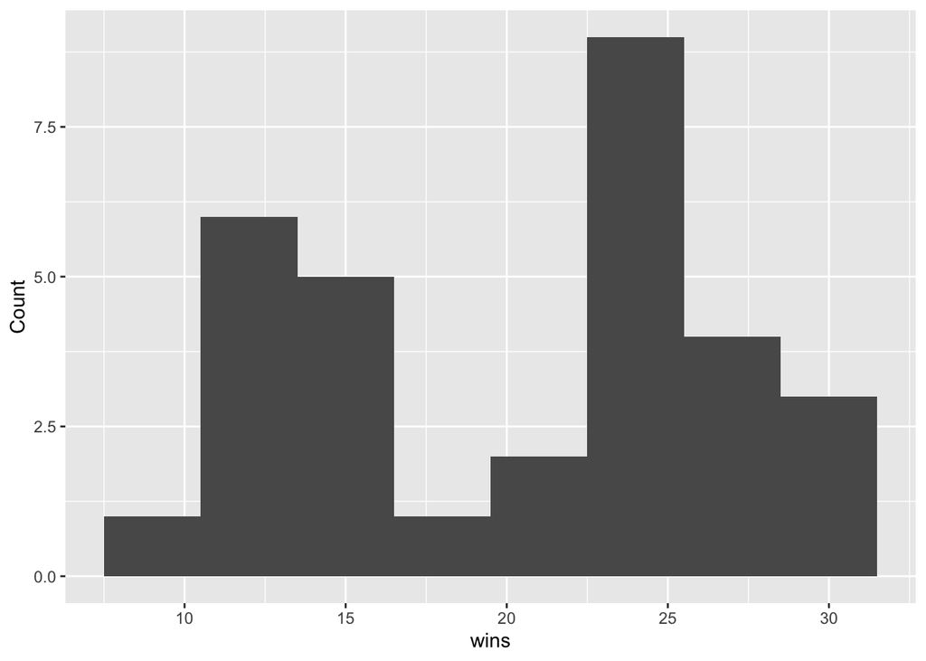

```r
wins_ducks<-wins_tidy%>%filter(Team=="Ducks")
univar_plot<-ggplot(data=wins_ducks,aes(x=Wins))+xlab("wins")+ylab("Count")
univar_plot+geom_histogram(binwidth = 3)
```

**(Q2)** Similar to (Q1), use the geom_density() function to create two density plots, with parameters adjust=0.5 and adjust=2, respectively.

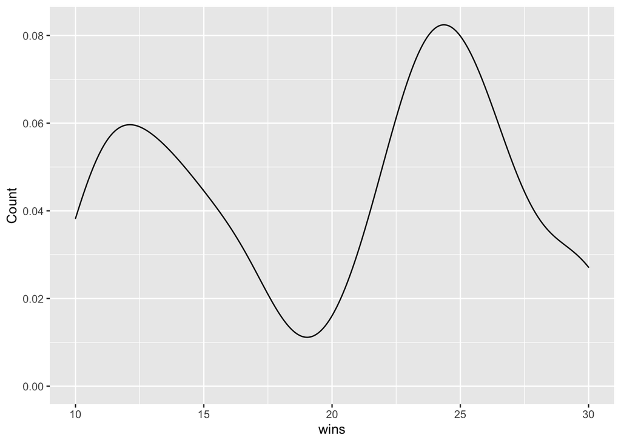

```r
univar_plot+geom_density(adjust=0.5)
```

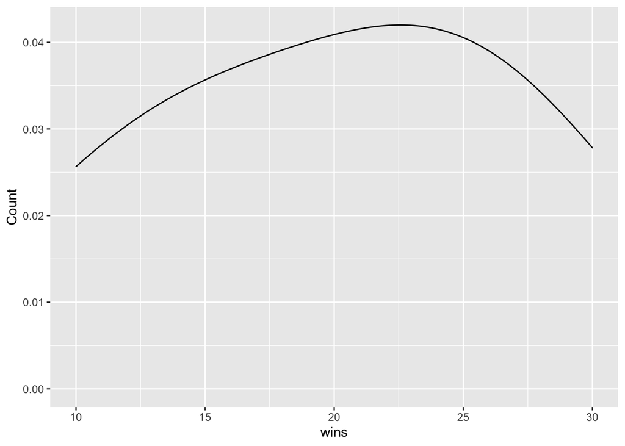

```r
univar_plot+geom_density(adjust=2)
```

**the difference between the two plots?**

**(Q3)** Next, let’s create a bivariate plot. First, from *wins_tidy*, create a data frame called wins_teams with columns: Year, Ducks, Eagles, as well as the other teams. For example, the column Ducks represent the Wins of the team Ducks for different years. You can use a combination of select and pivot_wider to do so.

```r
wins_team<-wins_tidy%>%pivot_wider(names_from = Team,values_from=Wins)%>%select(-Total)
wins_team
```

```
## # A tibble: 31 × 9
##    Year  Ducks Eagles Hawks Kingfishers Ostriches  Owls Penguins Storks
##    <chr> <dbl>  <dbl> <dbl>       <dbl>     <dbl> <dbl>    <dbl>  <dbl>
##  1 1990     30     24    20          16        13    19       23     20
##  2 1991     11     12    22          19        13    13       29     13
##  3 1992     30     37    33          12        10    18       30     18
##  4 1993     12     14    11          10        25    16       32     22
##  5 1994     24     32    20          17        10    13       33     19
##  6 1995     13     34    18          11        21    24       36     11
##  7 1996     25     17    21          11        13    24       12     15
##  8 1997     24     25    23          12        18    10       16     15
##  9 1998     27     33    18          11        24    20       34     14
## 10 1999     23     28    28          19        18    21       20     13
## # … with 21 more rows
```

Then from wins_team, use *geom_point()* to create a scatter plot, the x-axis is the Wins of Ducks, and the y-axis is the Wins of Eagles.

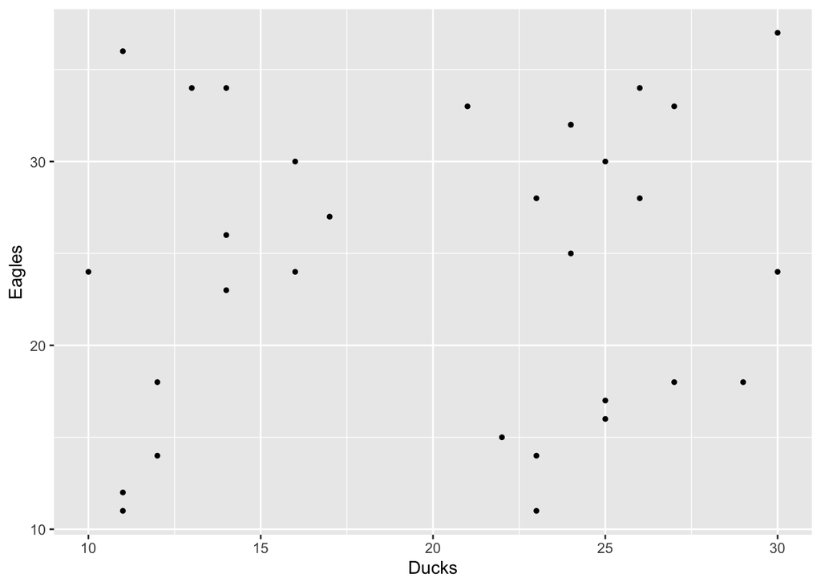

```r
bivariate_plot<-ggplot(data=wins_team,aes(x=Ducks,y=Eagles))+xlab("Ducks")+ylab("Eagles")
bivariate_plot+geom_point(size=1)
```